# Projekt pri predmetu Vitko upravljanje v inženirstvu

Luka Pečnik

06 januar 2020

# Uvod (Intro)

Quality and productivity improvement initiatives have come in and out of use in recent decades. Most of them were good in theory, but a little less practical or practical. more difficult to implement and did not produce the desired results consistently and over a longer period. The longest lasting still used was Six Sigma and they are respectively. it is still used by world-renowned companies. With the help of Six Sigma, they have achieved remarkable results. With the help of Six Sigma, they have achieved remarkable results. Success stories with Six Sigma have been written by companies like Motorola, General Electric, Federal Express, Johnson & Johnson and so on.

In addition to the success stories of large global companies, there are success stories of implementing Six Sigma or Lean approaches in smaller companies. This is the case with a paper manufacturing company that optimized the performance of printers and cutting machines by eliminating errors such as paper jams, incorrect print speeds, excessive ink consumption, etc. The production rate increased by 5% in the case of printing and 10% in the case of cutting. Another example of successful implementation is a battery manufacturing company that has achieved a waste of energy. oversupply of parts for battery production in warehouses. This was achieved by introducing the pull principle.

Despite the fact that Lean Six Sigma has achieved great success with many, we have also witnessed the failure of this approach several times. An example is a pharmaceutical company that made powder for tablet manufacturing. The machine that grinded this dust stuck, so they optimized and started grinding the powder more finely. Initially, the problem seemed to be resolved, but during the transport, the finer dust became stuck and became completely useless. Another example of a failed Lean Six Sigma implementation happened at 3M, where optimizations initially improved the business, but later it turned out that the approach was not properly implemented from an employee standpoint as creativity was reduced.

The purpose of this work was to present an example of how to undertake an analysis of the current situation in the company, and using it to determine what are the causes of the observed adverse effects and then perform optimization. The goal, through optimization, was to try to improve the situation and thus to show an example of the implementation of Lean Six Sigma approaches.

# Metodologija

The database for the implementation of the optimization case was downloaded from the Kaggle online database. It is a simulation of data from the HR department of a sales company in various fields [5].

The following section will outline the techniques we have used to analyze the base and realize optimization with lean and Six Sigma approaches.

## Analysis of numerical attributes

In the analysis of numerical attributes, we used more basic dimensions such as: maximum or. minimum value, range from minimum to maximum value, average, median and most common value, respectively. mode. In addition to the simple and very commonly used ones, we also used some measures, such as kurtosis, skewness, standard deviation, and interquartile spacing (IQR). With the help of these, in combination with the above, we can more precisely determine whether or not the value of a variable is a normal distribution [6].

### Koeficient sploščenosti (Flattening coefficient)

The flattening coefficient, at a perfectly normal distribution, equals 0 and determines how spiky or. the distribution is flattened.

### Koeficient asimetričnost (Asymmetry coefficient)

Also, in the case of a perfectly normal distribution, the asymmetry coefficient is 0. This determines the propensity of the distribution. It is calculated using the formulas below.

$Sk_{1} = \frac{povprecje - modus}{standardni odklon}$ oz. $Sk_{2} = \frac{3 \times (povprecje - modus)}{standardni odklon}$ [6]

### Standardni odklon (Standard deviation)

The standard deviation is a measure of dispersion calculated as the square root of the variance. The variance describes the distance of the value of the variable to the arithmetic mean.

$SD = \sqrt{\frac{\sum_{i = 1}^{n}(X_i-\overline{X})^2}{n-1}}$ [6]

### Interkvartilni razmik (Interquartile spacing)

Interquartile spacing describes the range of values of a variable if we cut off the lower and upper 25% of the value. It is therefore the distance between the first and third quartiles.

$IQR = Q_3-Q_1$ [6]

## Statistični testi (Statistical tests)

Data hypotheses or the links between them are checked by statistical tests, which are selected according to the data type and their properties. For each statistical test, we construct an alternative (H1) and a null (H0) hypothesis. The null hypothesis always says that there are no differences or differences between the data. connections, while the alternative hypothesis assumes that certain influences or the differences between the selected attributes. Before testing, we determine the risk level, which is usually 5%, and tells us what the chance is that we made a mistake if the null hypothesis is rejected. If the value of p (or significance) returned by the statistical test is less than the level of risk, we reject the null hypothesis and confirm the alternative, but if the value of p is greater than the level of risk, the alternative hypothesis cannot be confirmed [6].

### Test hi-kvadrat

The chi-square test is used to test the relationship between two categorical variables. The test tests the null hypothesis, which states that the variables are independent of each other. The contingent table shall be used. It assumes that the variables are independent and each has at least two categories, that the samples in the database are independent, respectively. each falls into one cell of the contingent table and that we have a large enough sample [6].

### T-test

In the t-test, we compare arithmetic means or. average values of two and therefore fall under parametric tests. Because t-tests measure differences in average values, it is also essential that the numerical variable is normally distributed across all groups of the categorical variable [6].

### ANOVA test

It is a statistical test similar to the t-test, but in this case we compare the arithmetic means of three or more groups. The procedure tests the null hypothesis for multiple independent averages for populations. An important value of the test is the F-statistic, with its large value denying the null hypothesis [6].

### Mann-Whitney U-test

The Mann-Whitney U-test, also called the Wilcoxon test, is used as an alternative to the parametric t-test when the assumption of a normal arrangement of a continuous variable is not fulfilled [6].

### Kruskal-Wallis test

The Kruskal-Wallis test is used as an alternative to the ANOVA test if the assumption of normal distribution is not met [7].

### Korelacija

We use correlation tests to measure the relationship between two numerical variables. We want to determine whether there is a linear relationship between the variables tested [6]. We used two correlation coefficients with respect to the distribution of variables, namely the Spearman correlation coefficient and the Pearson correlation coefficient [6].

The correlation is estimated based on the value of the coefficient. It can be very weak($0 < |r| < 0,2$), weak ($0,2 \le |r| < 0,4$), medium strong ($0,4 \le |r| < 0,6$), strong ($0,6 \le |r| < 0,8$) and very strong ($|r| \ge 0,8$). According to the sign we distinguish between negative and positive correlation [6].

#### Spearmanov korelacijski koeficient (Spearman correlation coefficient)

Ranks are used instead of actual values for calculation, so it is useful for testing variables without a normal distribution. those that contain many discrepancies [6].

#### Pearsonov korelacijski koeficient (Pearson correlation coefficient)

Pearson's correlation test is parametric and tests if there is a linear relationship between the values of two continuous variables. It assumes that they have a normal distribution with no deviating values [6].

## Linearna regresija

Linearna regresija je postopek, pri katerem za izhodno spremenljivko $y$ iščemo linearno kombinacijo spremenljivk $x_i$. Splošno formulo lahko zapišemo kot:

Linear regression is a procedure in which we search for a linear combination of variables xi for the output variable y. The general formula can be written as:

$$y = \beta_0 + \beta_1x_1 + \dots + \beta_kx_k,$$

pri čemer so (whereby they are) $\beta_i$ uteži posameznih neodvisnih spremenljivk oz. regresijski koeficienti (weights of individual independent variables, respectively regression coefficients)[8]. Za določanje teh uteži ponavadi uporabimo vsoto najmanjših kvadratov oz. vsoto kvadratnih napak. Seveda želimo oboje minimizirati (We usually use the sum of the least squares and / or squares to determine these weights. the sum of the squared errors. Of course, we want to minimize both). Po določitvi koeficientov se na podlagi njihovih p-vrednosti odločimo ali so pomembni za napovedni model (After determining the coefficients, we decide on the basis of their p-values whether they are relevant to the predictive model.). Meja je najpogosteje 0,05. Torej v primeru, da je p-vrednost manjša od 0,05 neodvisno spremenljivko uporabimo v napovednem modelu (The limit is usually 0.05. So, if the p-value is less than 0.05, the independent variable is used in the predictive model) [9].

## Logistična regresija

Logistic regression is a statistical method for analyzing a multitude of data with one or more independent variables that determine categorical output. The logistic regression predictive model operates on the principle of a sigmoid function, which determines the optimal threshold in a way that maximizes the number of correct predictions with respect to input attributes. The threshold can be easily determined using the confusion matrix. contingency tables [10].

Prvi korak je izračun verjetnosti, da opazovan primerek pripada razredu 1 (za primer, da imamo izhoda 0 in 1). Splošna formula se glasi (The first step is to calculate the probability that the observed specimen belongs to class 1 (in case we have outputs 0 and 1). The general formula is:):

$$P(y=1)=\frac{1}{1 + e^{-(\beta_0 + \beta_1x_1 + \dots + \beta_kx_k)}}$$

The coefficients $\beta_i$ for the input attributes are chosen in such a way as to minimize the prediction error. Even with this type of regression, we check the p-values and coefficients to determine the appropriate predictive model [10].

Poznamo binarno logistično regresijo oz. logistično regresijo z dvema možnima izhodoma, logistično regresijo za tri ali več nominalnih kategoričnih izhodov in logistično regresijo za tri ali več ordinalnih kategoričnih izhodov [10].

We know binary logistic regression. logistic regression with two possible outputs, logistic regression for three or more nominal categorical outputs, and logistic regression for three or more ordinal categorical outputs [10].

## Cohenov kappa koeficient (Cohen's kappa coefficient)

The kappa statistic is often used to evaluate the match between two estimators evaluating the same binary measurement. The coefficient measures the percentage of units in which estimates match according to the expected coincidence resulting from chance. The contingency table is used to calculate the coefficient. Depending on the value of the coefficient, the match may be weak ($K < 0,2$), partial ($0,2 \le K < 0,4$), medium strong ($0,4 \le K < 0,8$), strong ($0,6 \le K < 0,8$) or very strong močno ($0,8 \le K < 1$) [11].

## Bland-Altman plot

The Bland-Altman plot gives us a graphical representation of the differences compared to the average of two measurement techniques. The horizontal lines show the mean difference and the 95% confidence interval of the difference. We can understand the comparability of the measurement of the two techniques. For the techniques to be comparable, the calculated differences must be small. Of course, this method is used when we have continuous values for the measured variable [11].

# Opis vzorca (Description of the sample)

The database contained 14999 entries and had basically the following attributes: satisfaction_level, last_evaluation, number_project, average_monthly_hours, time_spend_company, work_accident, left, promotion_last_5years, sales and salary. The meaning is described in the table below.

[output not shown]

The base chosen was basically a simulation of the company, and most likely this is the reason that it does not contain suspicious or missing values. In the following, we focused mainly on the attributes satisfaction_level, last_evaluation, number_project, time_spend_company, left, promotion_last_5years and salary. They describe the level of satisfaction of employees, the estimates of their work, the number of projects they work on, information on if a person has left the company, if the person has progressed in the last five years, and the level of the employee's salary.

### Analiza atributov (Attribute analysis)

In this section, an analysis of the individual attributes in the database was performed.

#### Numerični atributi (Numerical attributes)

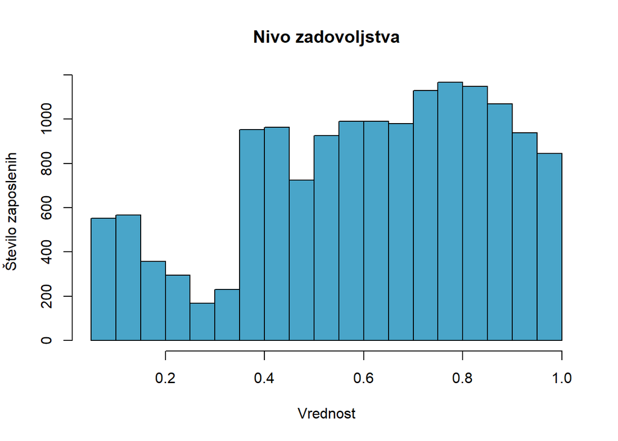

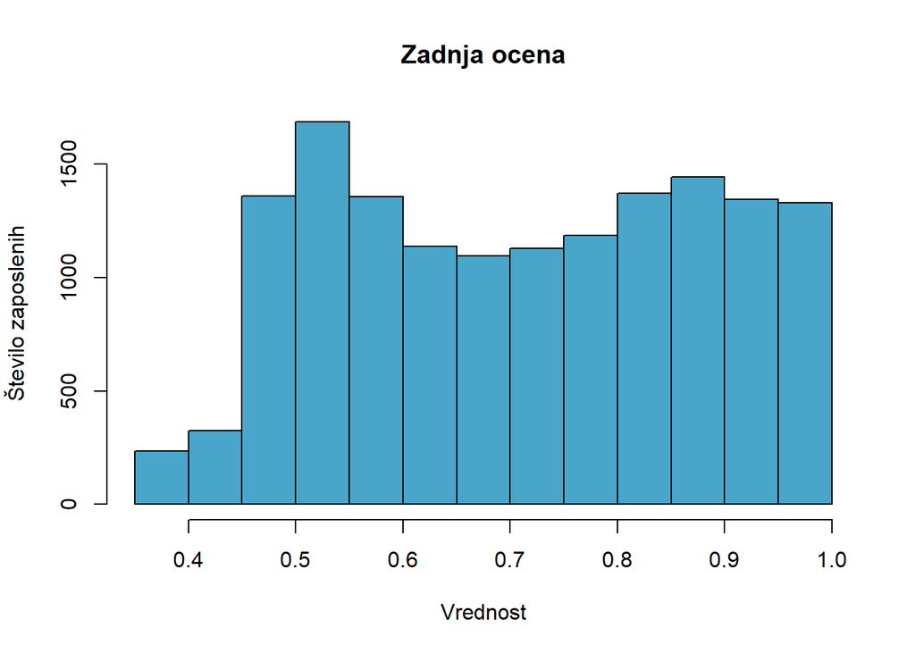

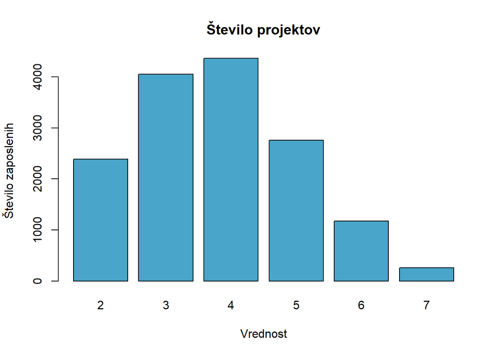

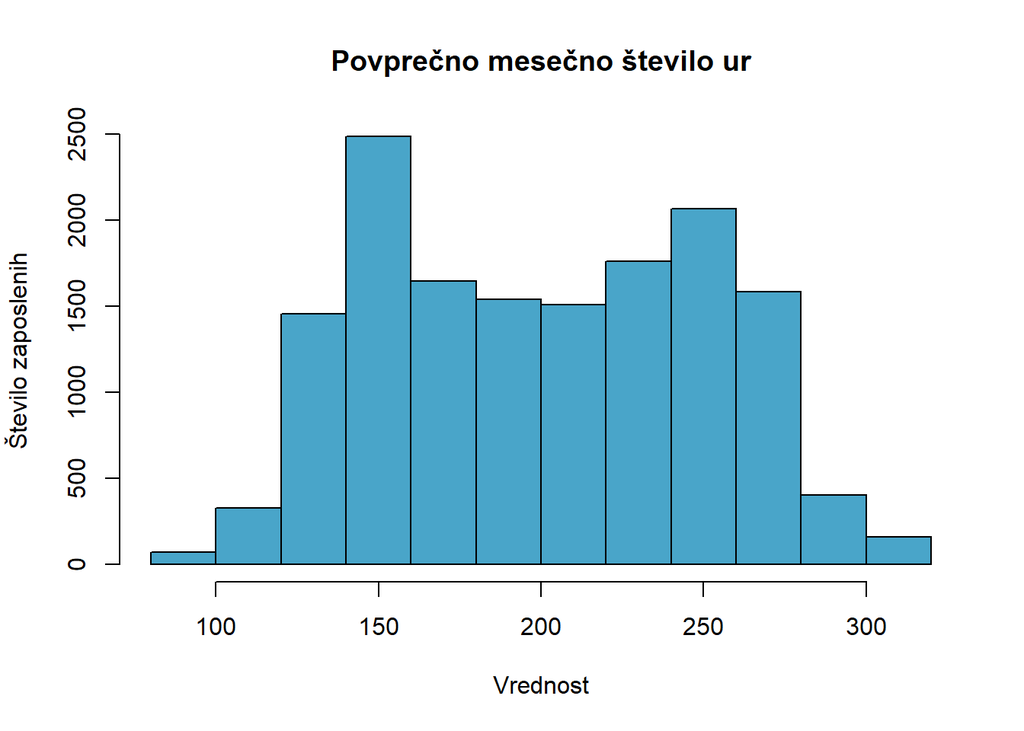

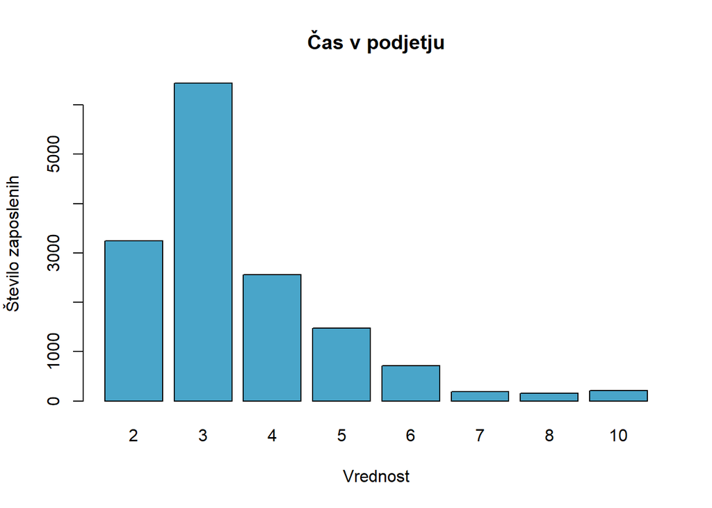

|  | Ime | Pomen | Povprečje | Mediana | Maksimum | Minimum | Standardni.odklon | IQR | Rang | Kurtosis | Skewness | Modus | Normalna.porazdelitev |
| --- | --- | --- | --- | --- | --- | --- | --- | --- | --- | --- | --- | --- | --- |
| 1 | satisfaction_level | Nivo zadovoljstva | 0.6128335 | 0.64 | 1 | 0.09 | 0.2486307 | 0.38 | 0.91 | -0.6713455 | -0.47626507 | 0.10 | ne |
| 2 | last_evaluation | Zadnja ocena | 0.7161017 | 0.72 | 1 | 0.36 | 0.1711691 | 0.31 | 0.64 | -1.2392621 | -0.02661643 | 0.55 | ne |
| 3 | number_project | Število projektov | 3.8030535 | 4.00 | 7 | 2.00 | 1.2325924 | 2.00 | 5.00 | -0.4960467 | 0.33763807 | 4.00 | da |
| 4 | average_montly_hours | Povprečno mesečno število ur | 201.0503367 | 200.00 | 310 | 96.00 | 49.9430994 | 89.00 | 214.00 | -1.1352519 | 0.05283142 | 135.00 | ne |
| 5 | time_spend_company | Čas v podjetju | 3.4982332 | 3.00 | 10 | 2.00 | 1.4601362 | 1.00 | 8.00 | 4.7701835 | 1.85294838 | 3.00 | ne |

#### Nominalni atributi (Nominal attribtes)

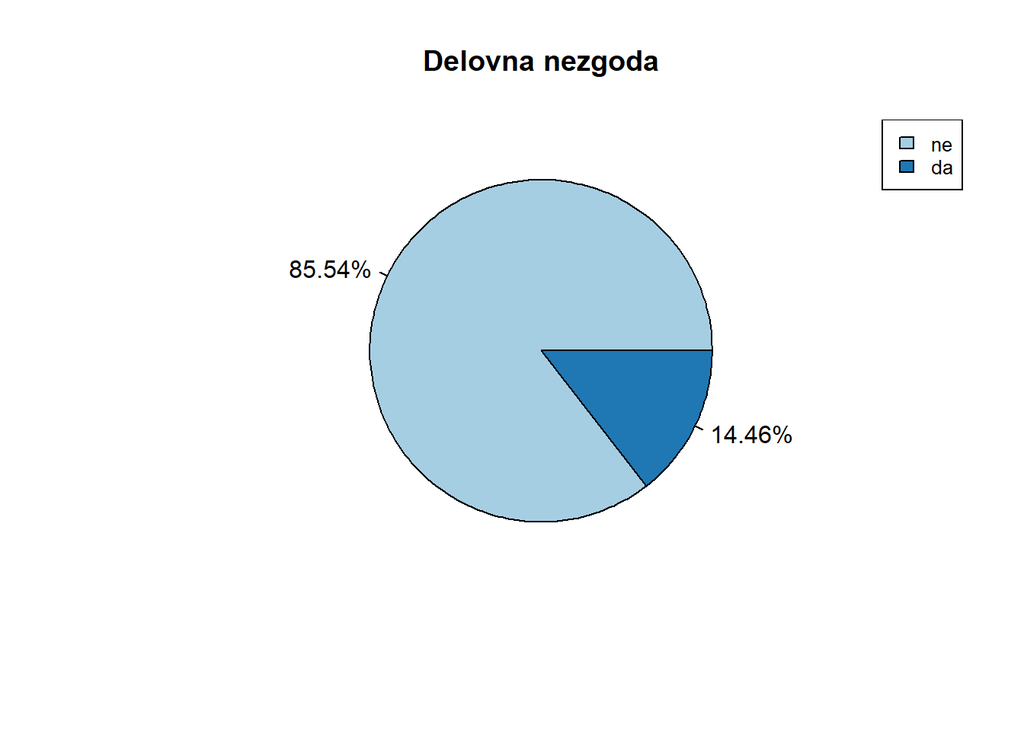

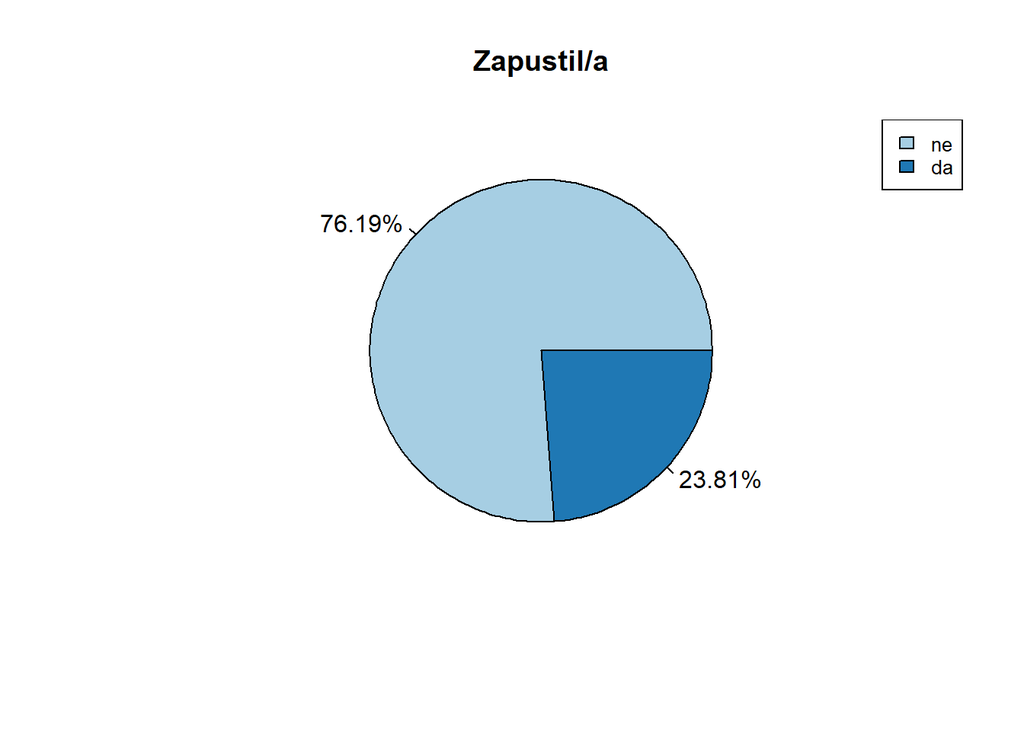

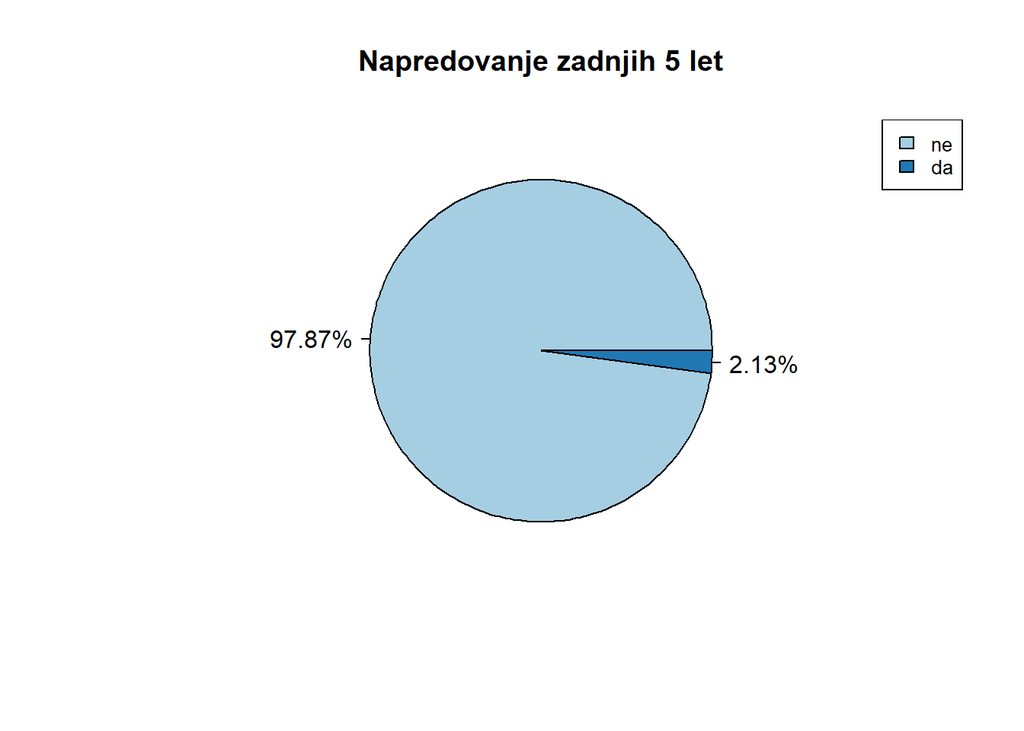

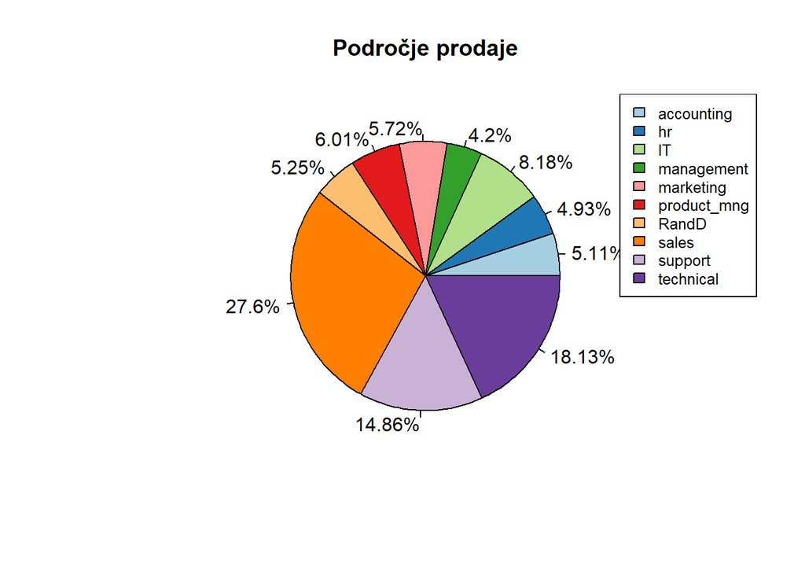

[output not shown]

#### Ordinalni atributi

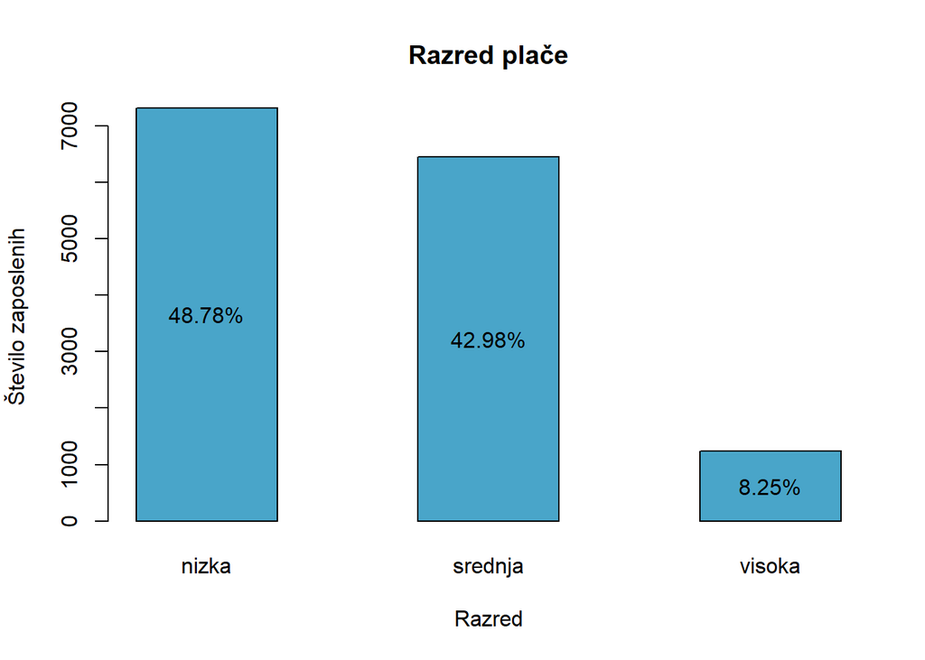

|  | Ime | Razredi.s.frekvencami |
| --- | --- | --- |
| 1 | Razred plače | visoka: 1237 (8.25%), nizka: 7316 (48.78%), srednja: 6446 (42.98%) |

# Optimizacija

## Statistični testi (Statistical tests)

To test the correlation between numerical attributes, we used the Spearman test in all cases, since only one numerical attribute had a normal distribution, namely the number of projects. We did not show the correlation graphs between the variables due to the amount of data as they were very opaque.

|  | Atribut.1 | Atribut.2 | Korelacijski.koeficient | Vrednost.korelacijskega.koeficienta | Vrednost.signifikance | Statistično.značilna.povezava |
| --- | --- | --- | --- | --- | --- | --- |
| 1 | Nivo zadovoljstva | Zadnja ocena | spearman | 0.162406916 | 3.582503e-89 | DA |
| 2 | Nivo zadovoljstva | Število projektov | spearman | 0.005785845 | 4.786090e-01 | NE |
| 3 | Nivo zadovoljstva | Povprečno mesečno število ur | spearman | 0.061999587 | 2.966043e-14 | DA |
| 4 | Nivo zadovoljstva | Čas v podjetju | spearman | -0.139427917 | 5.454326e-66 | DA |
| 5 | Zadnja ocena | Število projektov | spearman | 0.350399265 | 0.000000e+00 | DA |
| 6 | Zadnja ocena | Povprečno mesečno število ur | spearman | 0.342061328 | 0.000000e+00 | DA |
| 7 | Zadnja ocena | Čas v podjetju | spearman | 0.161154132 | 8.185841e-88 | DA |
| 8 | Število projektov | Povprečno mesečno število ur | spearman | 0.397855197 | 0.000000e+00 | DA |
| 9 | Število projektov | Čas v podjetju | spearman | 0.251971007 | 6.311836e-216 | DA |
| 10 | Povprečno mesečno število ur | Čas v podjetju | spearman | 0.168750252 | 3.190476e-96 | DA |

All tested pairs, except for the number of projects - satisfaction level, had a statistically significant correlation, but the result was most likely because our database was quite large and contained 14999 entries. For this reason, in determining which attributes were actually correlated, the value of the correlation coefficient was also taken into account, thus negating the correlation between pairs where the coefficient was very low. Thus, based on the obtained results, we decided to pay more attention to pairs that had an absolute correlation coefficient value greater than 0.15 and influenced the output values of the attributes, which we optimized in the cases described later.

We also checked the statistical association between the individual nominal and ordinal attributes using the chi-square test. Here again, in only one case did we find that there was no statistically significant correlation between the attributes of the wage class and the work accident.

|  | Atribut.1 | Atribut.2 | Vrednost.hi2 | Vrednost.signifikance | Statistično.značilna.povezava |
| --- | --- | --- | --- | --- | --- |
| 1 | Delovna nezgoda | Zapustil/a | 357.562360 | 9.558240e-80 | DA |
| 2 | Delovna nezgoda | Napredovanje zadnjih 5 let | 22.334581 | 2.290447e-06 | DA |
| 3 | Delovna nezgoda | Področje prodaje | 17.461493 | 4.196082e-02 | DA |
| 4 | Delovna nezgoda | Razred plače | 1.510645 | 4.698590e-01 | NE |
| 5 | Zapustil/a | Napredovanje zadnjih 5 let | 56.261627 | 6.344155e-14 | DA |
| 6 | Zapustil/a | Področje prodaje | 86.825474 | 7.042130e-15 | DA |
| 7 | Zapustil/a | Razred plače | 381.225047 | 1.652087e-83 | DA |
| 8 | Napredovanje zadnjih 5 let | Področje prodaje | 350.908581 | 3.970084e-70 | DA |
| 9 | Napredovanje zadnjih 5 let | Razred plače | 148.159385 | 6.723545e-33 | DA |
| 10 | Področje prodaje | Razred plače | 700.919342 | 3.621445e-137 | DA |

The correlation between numerical and nominal and ordinal attributes was verified by statistical tests: ANOVA, t-test, Kruskal-Wallis and Mann Whitney U test. Before testing, we hypothesized:

1. Nivo zadovoljstva glede na plačilni razred (Level of satisfaction with pay grade):

H1: The level of satisfaction is higher for those with a higher pay grade. H0: There is no difference in satisfaction.

2. Nivo zadovoljstva glede na področje prodaje (Satisfaction level by sales area:):

H1: The level of satisfaction will vary depending on which sales area employees are working on. H0: There is no difference in satisfaction.

3. Ocena zaposlenega glede na plačilni razred (Employee rating by pay grade):

H1: There are differences in pay grades according to employee ratings. H0: There is no difference in pay grade estimates.

4. Ocena zaposlenega glede na področje prodaje (Employee rating by sales area:):

H1: Employee ratings vary by sales area. H0: There are no differences in sales estimates.

5. Razred plače glede na število projektov (Salary class by number of projects):

H1: The pay grade of employees varies with the number of projects completed. H0: There is no difference in pay grade in terms of the number of projects implemented.

6. Število projektov glede na področje prodaje (Number of projects by field of sale):

H1: There are differences in the number of completed projects by area of sales. H0: There are no differences in the number of completed projects in individual sales areas.

7. Plačilni razred glede na povprečno število mesečnih ur (Pay grade based on average monthly hours):

H1: The pay grade of employees varies with the average number of monthly hours. H0: There is no difference between the pay classes according to the average number of monthly hours.

8. Področje prodaje glede na povprečno število mesečnih ur (Sales by average monthly hours):

H1: The average number of hours per month varies by sales area. H0: There is no difference in the average number of hours per month by area.

9. Plačilni razred glede na oddelano število ur v podjetju (Pay grade based on the number of hours worked in the company):

H1: There are differences in pay grade depending on how many hours an individual spends inside a business. H0: Difference with job no. there are no hours in the company.

10. Področje prodaje glede na oddelano število ur v podjetju (Sales area by number of hours worked in the company):

H1: The number of hours worked by an individual within a company varies depending on their area of sales. H0: Difference in division no. hours by sales area.

11. Zadovoljstvo glede na to ali se je zaposlenemu pripetila delovna nesreča (Satisfaction as to whether an employee has experienced a work accident):

H1: Employee satisfaction varies depending on whether or not a work accident has occurred. H0: There are no differences in job satisfaction.

12. Zadovoljstvo zaposlenih glede na to ali so zapustili podjetje (Employee satisfaction according to whether they left the company):

H1: Satisfaction is lower for those who left the company. H0: There is no difference in satisfaction between employees and those who left the company.

13. Zadovoljstvo zaposlenih glede na to ali so v zadnjih petih letih napredovali (Employee satisfaction as to whether they have progressed in the last five years):

H1: Those who have progressed in the last 5 years are more satisfied. H0: There is no difference in satisfaction.

14. Ocena zaposlenih glede na to ali se jim je pripetila delovna nesreča (Employee assessment of whether or not a work accident occurred):

H1: There are differences in assessment as to whether an employee has experienced a work accident. H0: There is no difference in estimates of work accidents

15. Ocena zaposlenih glede na to ali so podjetje zapustili (Employee rating based on whether they left the company):

H1: Estimates differ from those that are not companies or. they left. H0: There is no difference in ratings.

16. Ocena zaposlenih glede na to ali so v zadnjih 5. letih napredovali (Assessment of employees according to whether they have progressed in the last 5 years):

H1: Employee ratings vary depending on whether they have progressed in the last 5 years. H0: There is no difference in ratings.

17. Delovne nesreče glede na število projektov (Occupational accidents by number of projects):

H1: There are differences in the number of projects depending on whether an employee has a work accident. H0: There is no difference in the number of projects by work accident.

18. Število projektov v povezavi s tem ali je zaposleni zapustil podjetje (Number of projects related to whether an employee left the company):

H1: There are differences in the number of projects between those who left or left the company. they did not leave. H0: There is no difference in the number of projects.

19. Število projektov glede na napredovanje v zadnjih petih letih (Number of projects in terms of progress over the last five years):

H1: There are differences in the number of projects between those who have made progress in the last 5 years. they did not advance. H0: Difference in no. there are no projects.

20. Delovne nesreče glede na povprečno število ur na mesec (Occupational accidents according to the average number of hours per month:):

H1: The average number of hours per month affects work accidents. H0: There is no difference in the number of work accidents on the average hours worked.

21. Zapustitev podjetja glede na povprečno število ur na mesec (Leaving company based on average hours per month):

H1: There is a correlation between the average number of hours per month and whether an employee has left the company. H0: There is no connection.

22. Napredovanje glede na povprečno število ur na mesec (Progress over average hours per month):

H1: The average number of monthly hours has influenced the progression over the last 5 years. H0: No progression affected.

23. Delovne nesreče glede na čas preživet znotraj podjetja (Occupational accidents according to time spent inside the company.).

H1: The number of hours spent internally affects work accidents. H0: No impact.

24. Zapustitev podjetja glede na čas preživet znotraj podjetja (Leaving the company in terms of time spent inside the company).

H1: Spending time inside a business affects leaving. H0: No impact.

25. Napredovanje glede na čas preživet znotraj podjetja (Progress on time spent internally).

H1: Time spent internally influences promotion. H0: No impact.

The table below shows the test results.

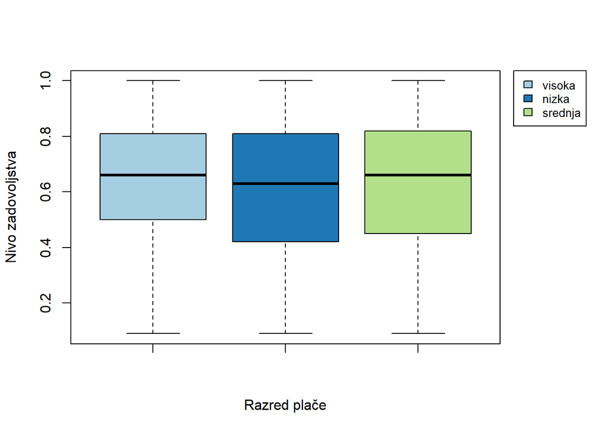

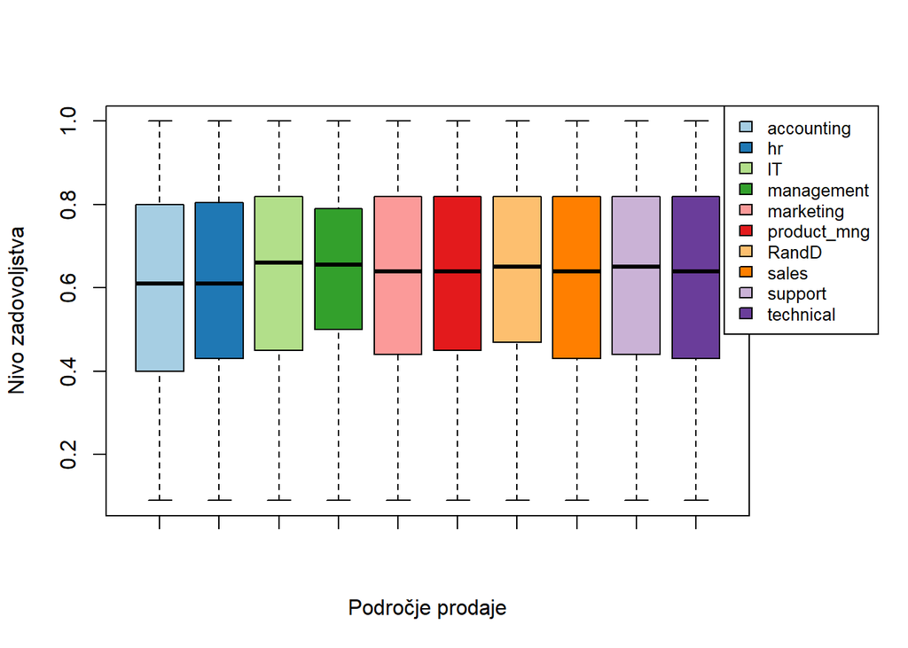

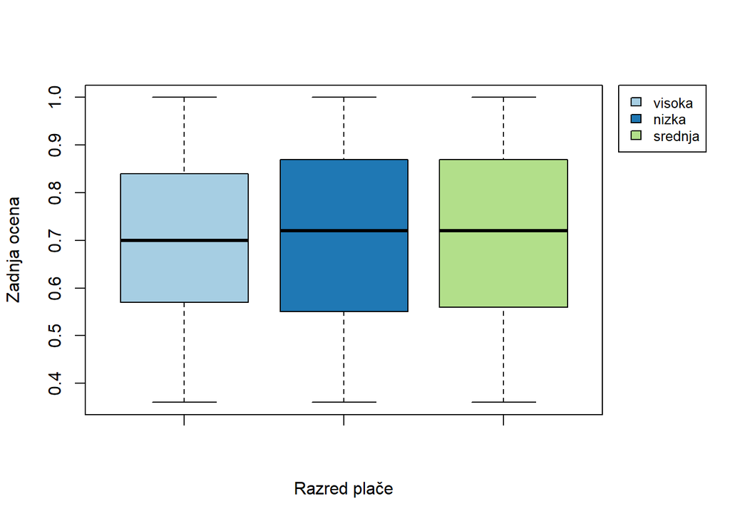

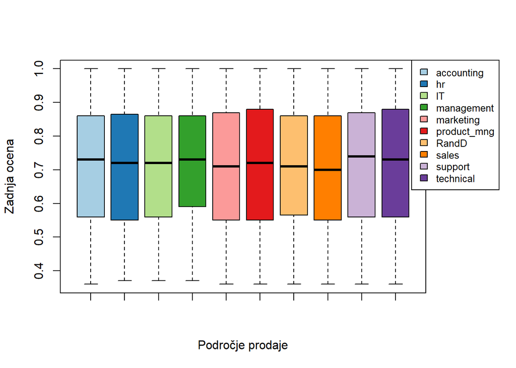

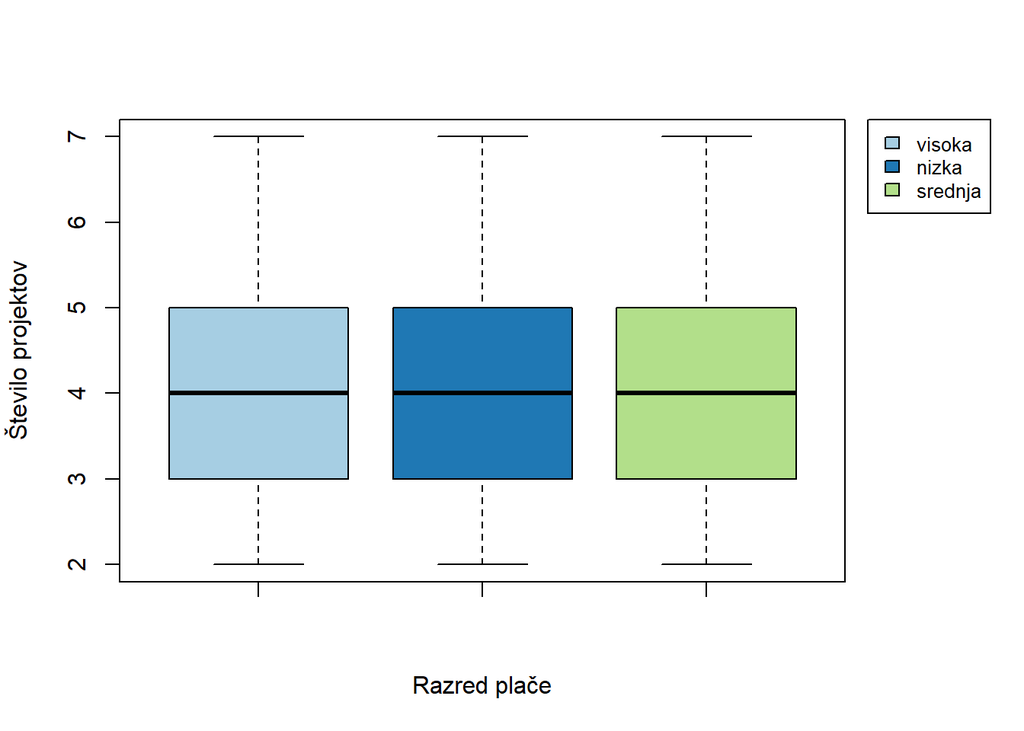

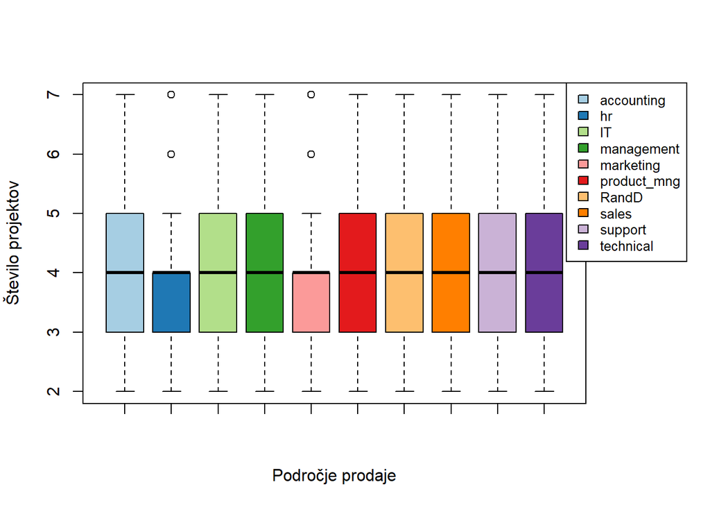

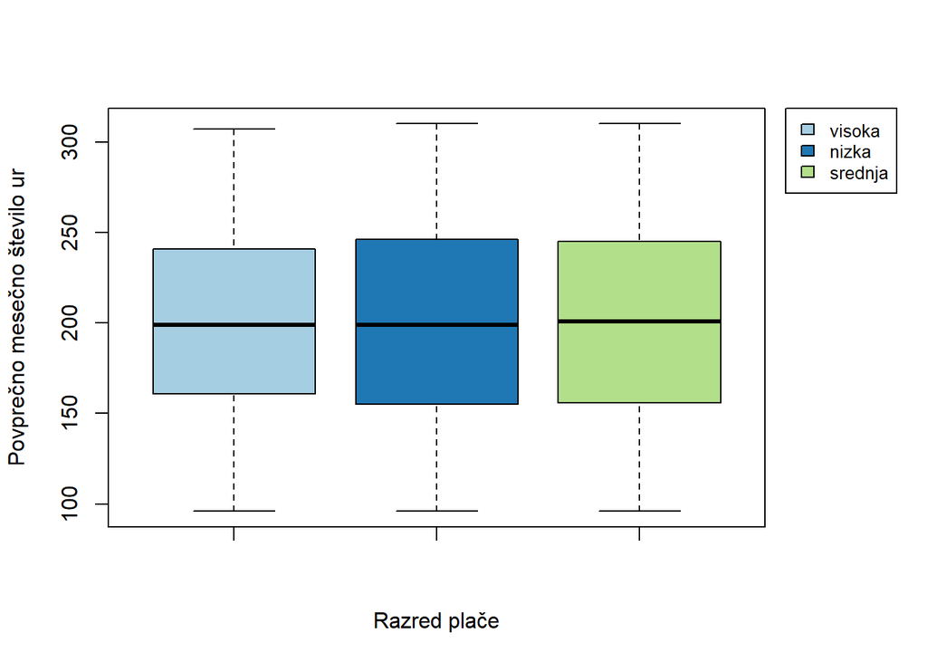

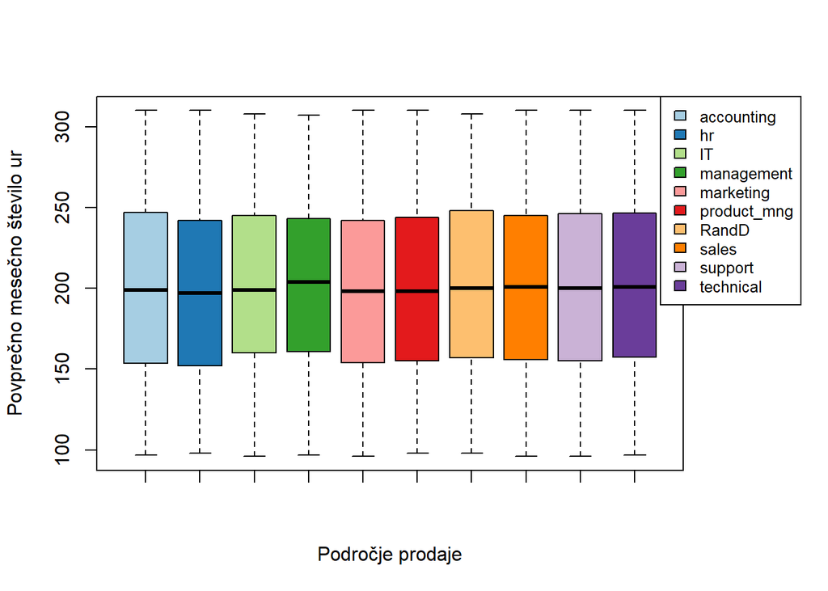

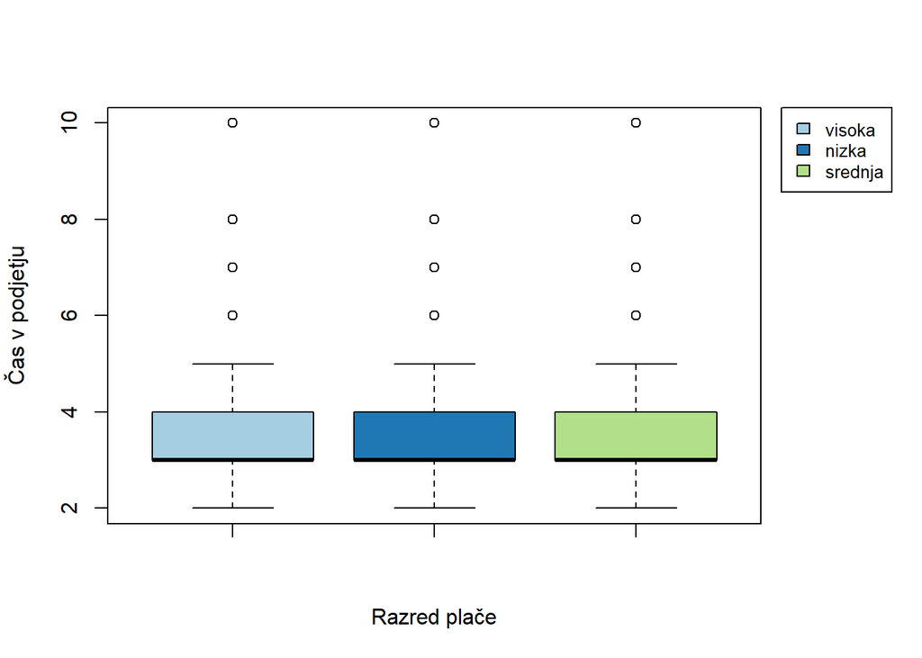

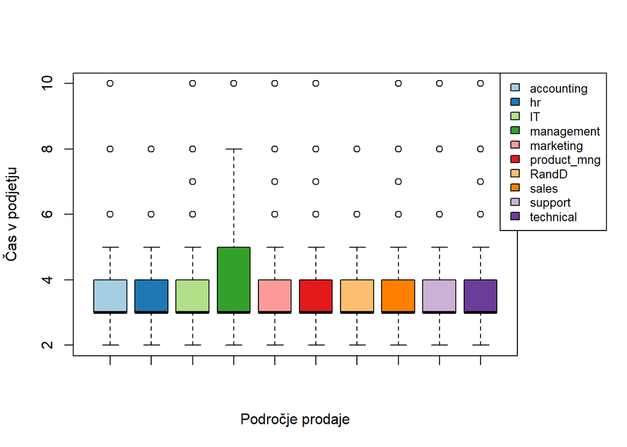

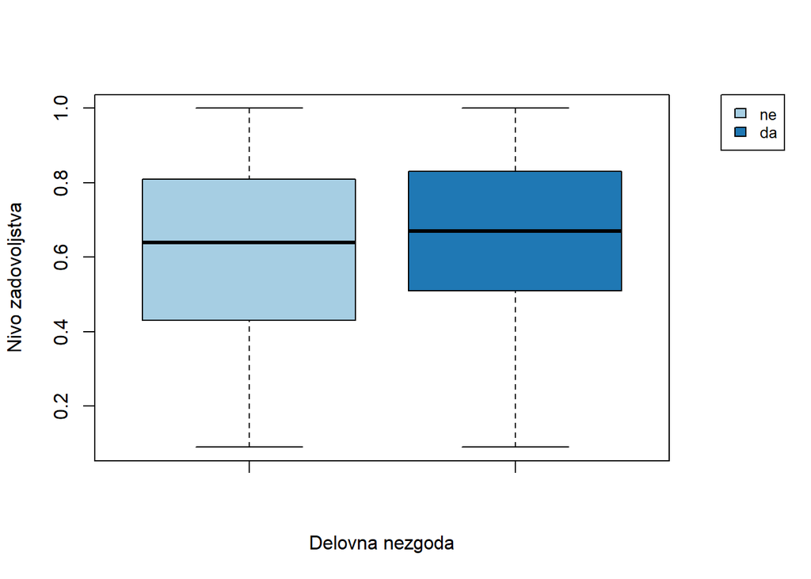

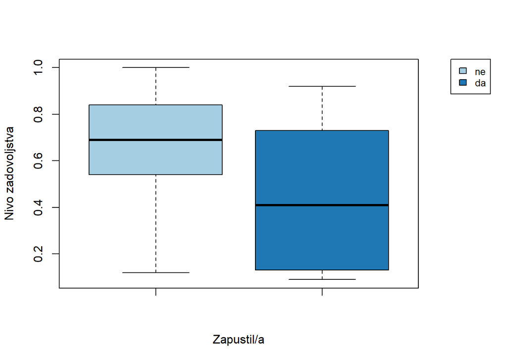

[13 more figures not shown]

|  | Atribut.1 | Atribut.2 | Uporabljen.test | Vrednost | Normalna.porazdelitev | Vrednost.signifikance | Statistično.značilna.razlika.med.skupinama |
| --- | --- | --- | --- | --- | --- | --- | --- |
| 1 | Razred plače | Nivo zadovoljstva | Kruskal-Wallis | 3.090290e+01 | NE | 1.947690e-07 | DA |
| 2 | Področje prodaje | Nivo zadovoljstva | Kruskal-Wallis | 1.829570e+01 | NE | 3.189376e-02 | DA |
| 3 | Razred plače | Zadnja ocena | Kruskal-Wallis | 5.940485e+00 | NE | 5.129086e-02 | NE |
| 4 | Področje prodaje | Zadnja ocena | Kruskal-Wallis | 1.494011e+01 | NE | 9.259419e-02 | NE |
| 5 | Razred plače | Število projektov | Kruskal-Wallis | 1.150141e+00 | NE | 5.626652e-01 | NE |
| 6 | Področje prodaje | Število projektov | Kruskal-Wallis | 3.441797e+01 | NE | 7.543983e-05 | DA |
| 7 | Razred plače | Povprečno mesečno število ur | Kruskal-Wallis | 5.663192e-01 | NE | 7.533995e-01 | NE |
| 8 | Področje prodaje | Povprečno mesečno število ur | Kruskal-Wallis | 7.247894e+00 | NE | 6.113273e-01 | NE |
| 9 | Razred plače | Čas v podjetju | Kruskal-Wallis | 1.384439e+00 | NE | 5.004641e-01 | NE |
| 10 | Področje prodaje | Čas v podjetju | Kruskal-Wallis | 5.452139e+01 | NE | 1.502398e-08 | DA |

[output cut: 15 more lines]

## Izvedba optimizacije (Optimization performance)

In this section, we describe two examples of optimization that we wanted to improve in the company based on the selected database.

### Primer 1

In the first case, we wanted to optimize the number of employees leaving. Using the statistical tests described above and logistic regression, we determined which attributes affect the output attribute “left,” which told us whether an employee left the company. Among the more influential were: the number of projects, the average number of monthly hours, the number of hours the employee spent in the company, the attribute that told or occurred to the employee of the accident, the attribute that said whether the employee had progressed in the last five years and pay the employee. In addition to the above, a strong correlation was indicated by the level of satisfaction, but this attribute was correlated with some of the above and therefore was not used in the forecasts.

Stanje pred optimizacijo je prikazano na naslednjem grafikonu.- The status before optimization is shown in the following chart.

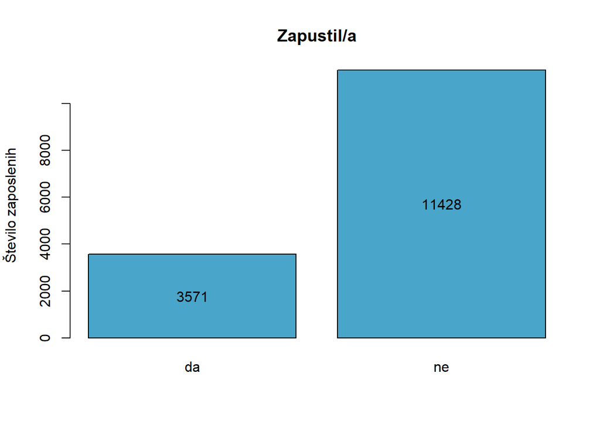

The Sigma value of the company state before leaving the attribute optimization was at about 2.20, according to the obtained DPMO 238082.5.

Because the nature of some attributes did not allow them to be easily modified according to their own wishes, we focused primarily on attributes that can influence the values and thus perform optimization. We have promoted some of our employees, making them responsible for a larger number of projects and thus raising their salaries. In addition to these improvements, we also allowed our employees to spend 30% more time at home. We found that with the improved balance, we would retain more employees.

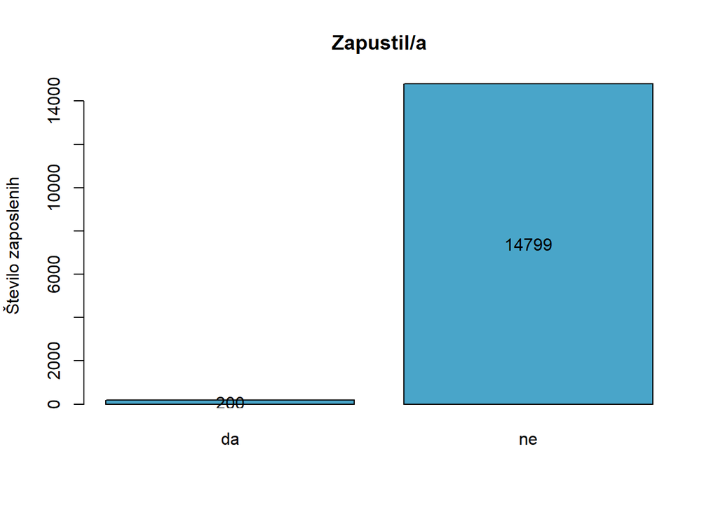

The sigma value of the company balance after optimization by attribute left was about 3.70 - 3.80, according to the obtained DPMO 13334.22.

To compare the differences between the state before and after optimization, we calculated a kappa coefficient whose value was 0.0181641. Because this coefficient was small, we could assume that the results are quite different, which we also expected in terms of optimization result and graphical representation.

### Primer 2

In the second case of optimization, we wanted to improve employee satisfaction. We found that it depends on the number of projects, salary and promotion. Because the output attribute was numerical here, we also used linear regression to help. The reason that satisfaction depends on the number of projects lies in the correlation of the number of projects with the employee's rating, because this attribute has an effect on satisfaction. Since we cannot easily raise our estimates, we preferred to focus on changing the number of projects.

The state of employee satisfaction before optimization is shown in the following chart.

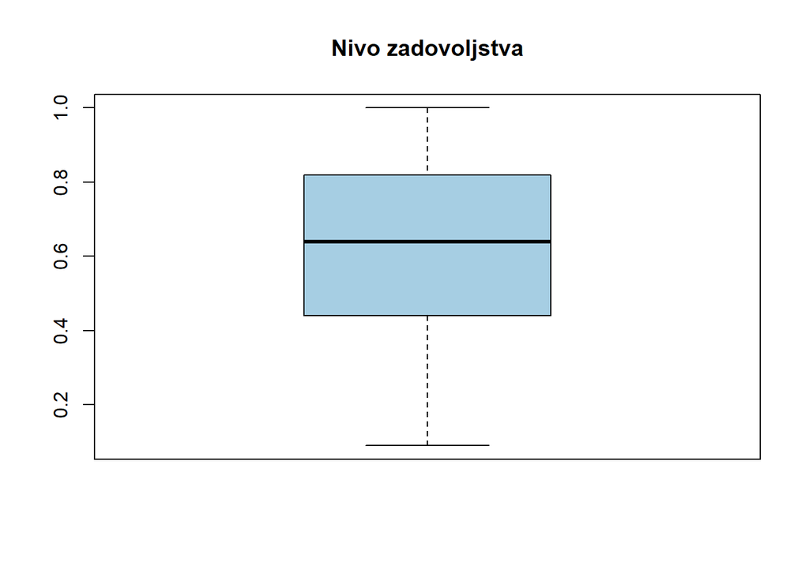

In calculating the sigma value, we assumed that the acceptable level of satisfaction was not lower than 0.55. According to the calculated DPMO 370624.7, a sigma value of 1.80 was obtained.

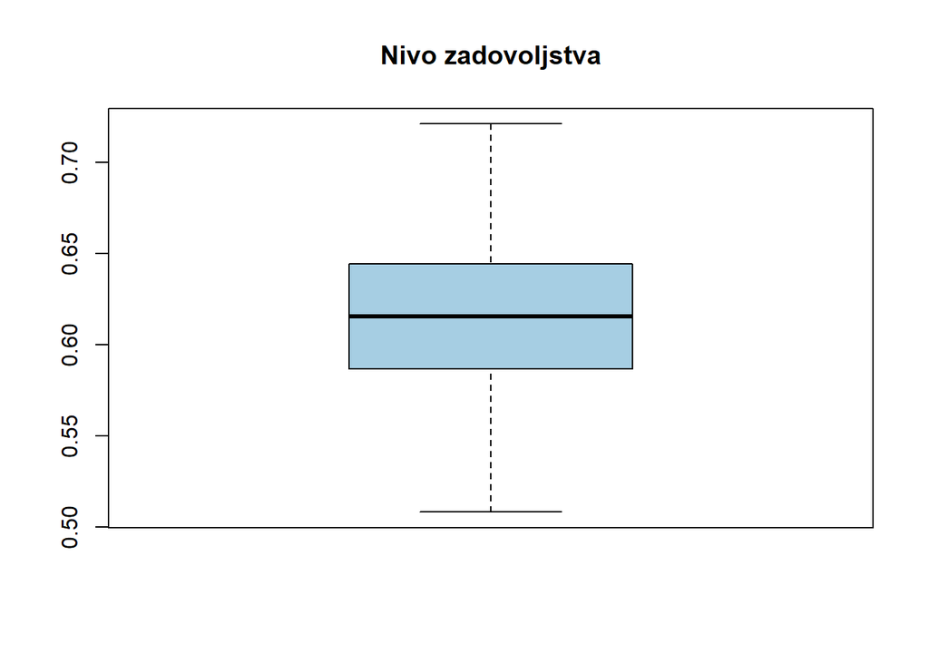

We obtained DPMO 59003.93 and hence a sigma value between 3.00 and 3.10.

We used the Bland-Altman chart to show the differences between the condition before and after optimization of the satisfaction level. Shown below.

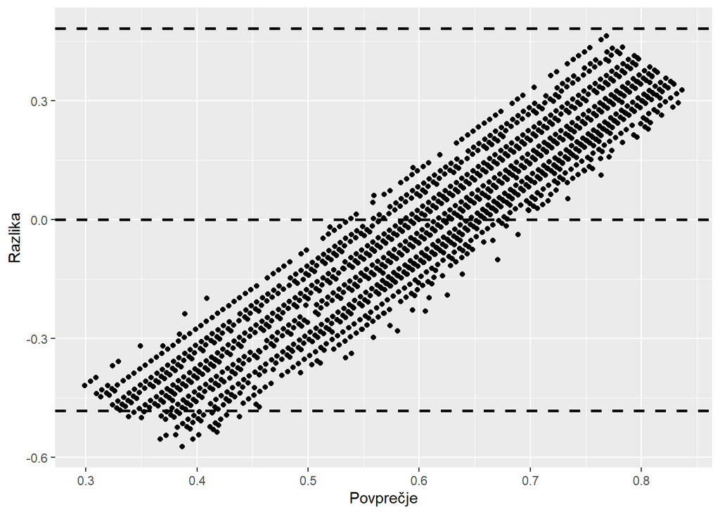

The obtained graph confirmed that the situation before and after optimization was different, as the differences were not located in the narrow area around the average difference shown by the mean horizontal line.

# Diskusija in zaključek (Discussion and conclusion)

In both optimization cases described above, we were able to improve the sigma value, so we can assume that the optimization was successful. In the first case, we were slightly more successful, because in the second case, it happened that the level of satisfaction of some employees even decreased, but it is true that we were able to significantly increase the minimum satisfaction. Using statistical methods and visualization, we also showed that in both cases the situation was different before and after optimization.

Suggestions for further improvements are: a more detailed statistical analysis of the influencing factors on the selected output variables, as well as gathering additional information on employees, and thus acquiring new attributes to help us optimize processes. Particularly important for the second optimization case, it would be to research and test ways to improve overall employee satisfaction without reducing the satisfaction of some. In addition to all of the above, you need to find a way to maintain the improvements you have made. An example of a problem that can occur if we do not maintain improvements is that employee satisfaction will decline again over time, and we will not be able to increase salaries and projects indefinitely.

# Literatura

[1] J. P. Zimmerman and J. Weiss, “Six sigma’s seven deadly sins,” vol. 44, pp. 62–67, Jan. 2005.

[2] N. Mandahawi, R. Al-Hadeethi, and S. Obeidat, “An application of customized lean six sigma to enhance productivity at a paper manufacturing company,” *Jordan Journal of Mechanical and Industrial Engineering*, vol. 6, pp. 103–109, Feb. 2012.

[3] U. Sharma, “Implementing lean principles with the six sigma advantage: How a battery company realized significant improvements,” *Journal of Organizational Excellence*, vol. 22, no. 3, pp. 43–52, 2003.

[4] S. S. Chakravorty, “Six sigma programs: An implementation model,” *International Journal of Production Economics*, vol. 119, no. 1, pp. 1–16, 2009.

[5] W. Walter, “Human resource.” https://www.kaggle.com/colara/human-resource/.

[6] P. P. Bržan and D. Dinevski, “Medicinske raziskave in biostatistika s praktičnimi primeri v programu spss,” pp. 110–138.

[7] datacamp, “Kruskal-wallis rank sum test.” https://www.rdocumentation.org/packages/stats/versions/3.6.2/topics/kruskal.test.

[8] G. A. Seber and A. J. Lee, *Linear regression analysis*. Wiley, 2012.

[9] M. Peixeiro, “Linear regression — understanding the theory.” https://towardsdatascience.com/linear-regression-understanding-the-theory-7e53ac2831b5, 2018.

[10] P. Chandrayan, “Logistic regression for dummies: A detailed explanation.” https://towardsdatascience.com/logistic-regression-for-dummies-a-detailed-explanation-9597f76edf46, 2019.

[11] P. P. Bržan, “Merjenje ujemanja,” Fakulteta za elektrotehniko, računalništvo in informatiko, Univerza v Mariboru, 2019.